# SpatialTraining

```python
# Import packages
import geopandas as gpd
import pandas as pd
```

```python
# Read in the data
full_data = gpd.read_file("D:\Project\Spatial\GeospatialKaggle\Data\DEC_lands\DEC_lands\DEC_lands.shp")

# View the data
full_data.head()
```

|  | OBJECTID | CATEGORY | UNIT | FACILITY | CLASS | UMP | DESCRIPTIO | REGION | COUNTY | URL | SOURCE | UPDATE_ | OFFICE | ACRES | LANDS_UID | GREENCERT | SHAPE_AREA | SHAPE_LEN | geometry |
| --- | --- | --- | --- | --- | --- | --- | --- | --- | --- | --- | --- | --- | --- | --- | --- | --- | --- | --- | --- |
| 0 | 1 | FOR PRES DET PAR | CFP | HANCOCK FP DETACHED PARCEL | WILD FOREST | None | DELAWARE COUNTY DETACHED PARCEL | 4 | DELAWARE | http://www.dec.ny.gov/ | DELAWARE RPP | 5/12 | STAMFORD | 738.620192 | 103 | N | 2.990365e+06 | 7927.662385 | POLYGON ((486093.245 4635308.586, 486787.235 4... |
| 1 | 2 | FOR PRES DET PAR | CFP | HANCOCK FP DETACHED PARCEL | WILD FOREST | None | DELAWARE COUNTY DETACHED PARCEL | 4 | DELAWARE | http://www.dec.ny.gov/ | DELAWARE RPP | 5/12 | STAMFORD | 282.553140 | 1218 | N | 1.143940e+06 | 4776.375600 | POLYGON ((491931.514 4637416.256, 491305.424 4... |
| 2 | 3 | FOR PRES DET PAR | CFP | HANCOCK FP DETACHED PARCEL | WILD FOREST | None | DELAWARE COUNTY DETACHED PARCEL | 4 | DELAWARE | http://www.dec.ny.gov/ | DELAWARE RPP | 5/12 | STAMFORD | 234.291262 | 1780 | N | 9.485476e+05 | 5783.070364 | POLYGON ((486000.287 4635834.453, 485007.550 4... |
| 3 | 4 | FOR PRES DET PAR | CFP | GREENE COUNTY FP DETACHED PARCEL | WILD FOREST | None | None | 4 | GREENE | http://www.dec.ny.gov/ | GREENE RPP | 5/12 | STAMFORD | 450.106464 | 2060 | N | 1.822293e+06 | 7021.644833 | POLYGON ((541716.775 4675243.268, 541217.579 4... |
| 4 | 6 | FOREST PRESERVE | AFP | SARANAC LAKES WILD FOREST | WILD FOREST | SARANAC LAKES | None | 5 | ESSEX | http://www.dec.ny.gov/lands/22593.html | DECRP, ESSEX RPP | 12/96 | RAY BROOK | 69.702387 | 1517 | N | 2.821959e+05 | 2663.909932 | POLYGON ((583896.043 4909643.187, 583891.200 4... |

```python
type(full_data)
```

```
geopandas.geodataframe.GeoDataFrame
```

```python
data = full_data.loc[:, ["CLASS", "COUNTY", "geometry"]].copy()
```

```python
# How many lands of each type are there?
data.CLASS.value_counts()
```

```
WILD FOREST                   965
INTENSIVE USE                 108
PRIMITIVE                      60
WILDERNESS                     52
ADMINISTRATIVE                 17
UNCLASSIFIED                    7
HISTORIC                        5
PRIMITIVE BICYCLE CORRIDOR      4
CANOE AREA                      1
Name: CLASS, dtype: int64
```

```python
# Select lands that fall under the "WILD FOREST" or "WILDERNESS" category
wild_lands = data.loc[data.CLASS.isin(['WILD FOREST', 'WILDERNESS'])].copy()
wild_lands.head()
```

|  | CLASS | COUNTY | geometry |
| --- | --- | --- | --- |
| 0 | WILD FOREST | DELAWARE | POLYGON ((486093.245 4635308.586, 486787.235 4... |
| 1 | WILD FOREST | DELAWARE | POLYGON ((491931.514 4637416.256, 491305.424 4... |
| 2 | WILD FOREST | DELAWARE | POLYGON ((486000.287 4635834.453, 485007.550 4... |
| 3 | WILD FOREST | GREENE | POLYGON ((541716.775 4675243.268, 541217.579 4... |
| 4 | WILD FOREST | ESSEX | POLYGON ((583896.043 4909643.187, 583891.200 4... |

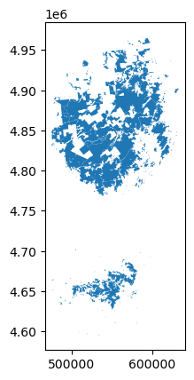

```python
wild_lands.plot()
```

```python
# View the first five entries in the "geometry" column
wild_lands.geometry.head()
```

```
0    POLYGON ((486093.245 4635308.586, 486787.235 4...
1    POLYGON ((491931.514 4637416.256, 491305.424 4...
2    POLYGON ((486000.287 4635834.453, 485007.550 4...
3    POLYGON ((541716.775 4675243.268, 541217.579 4...
4    POLYGON ((583896.043 4909643.187, 583891.200 4...
Name: geometry, dtype: geometry
```

```python
# Campsites in New York state (Point)
POI_data = gpd.read_file("D:\Project\Spatial\GeospatialKaggle\Data\DEC_pointsinterest\DEC_pointsinterest\Decptsofinterest.shp")
campsites = POI_data.loc[POI_data.ASSET=='PRIMITIVE CAMPSITE'].copy()

# Foot trails in New York state (LineString)
roads_trails = gpd.read_file("D:\Project\Spatial\GeospatialKaggle\Data\DEC_roadstrails\DEC_roadstrails\Decroadstrails.shp")
trails = roads_trails.loc[roads_trails.ASSET=='FOOT TRAIL'].copy()

# County boundaries in New York state (Polygon)
counties = gpd.read_file(r"D:\Project\Spatial\GeospatialKaggle\Data\NY_county_boundaries\NY_county_boundaries\NY_county_boundaries.shp")
```

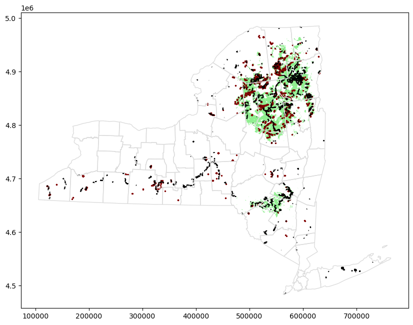

```python
# Define a base map with county boundaries
ax = counties.plot(figsize=(10,10), color='none', edgecolor='gainsboro', zorder=3)

# Add wild lands, campsites, and foot trails to the base map
wild_lands.plot(color='lightgreen', ax=ax)
campsites.plot(color='maroon', markersize=2, ax=ax)
trails.plot(color='black', markersize=1, ax=ax)
```

# Coordinate Reference Systems

```python
# Load a GeoDataFrame containing regions in Ghana
regions = gpd.read_file("D:\Project\Spatial\GeospatialKaggle\Data\ghana\ghana\Regions\Map_of_Regions_in_Ghana.shp")
print(regions.crs)
```

```
epsg:32630
```

```python
# Create a DataFrame with health facilities in Ghana
facilities_df = pd.read_csv("D:\Project\Spatial\GeospatialKaggle\Data\ghana\ghana\health_facilities.csv")
facilities_df.head()
```

|  | Region | District | FacilityName | Type | Town | Ownership | Latitude | Longitude |
| --- | --- | --- | --- | --- | --- | --- | --- | --- |
| 0 | Ashanti | Offinso North | A.M.E Zion Clinic | Clinic | Afrancho | CHAG | 7.40801 | -1.96317 |
| 1 | Ashanti | Bekwai Municipal | Abenkyiman Clinic | Clinic | Anwiankwanta | Private | 6.46312 | -1.58592 |
| 2 | Ashanti | Adansi North | Aboabo Health Centre | Health Centre | Aboabo No 2 | Government | 6.22393 | -1.34982 |
| 3 | Ashanti | Afigya-Kwabre | Aboabogya Health Centre | Health Centre | Aboabogya | Government | 6.84177 | -1.61098 |
| 4 | Ashanti | Kwabre | Aboaso Health Centre | Health Centre | Aboaso | Government | 6.84177 | -1.61098 |

```python
# Convert the DataFrame to a GeoDataFrame
facilities = gpd.GeoDataFrame(facilities_df, geometry=gpd.points_from_xy(facilities_df.Longitude, facilities_df.Latitude))
facilities.head()
```

|  | Region | District | FacilityName | Type | Town | Ownership | Latitude | Longitude | geometry |
| --- | --- | --- | --- | --- | --- | --- | --- | --- | --- |
| 0 | Ashanti | Offinso North | A.M.E Zion Clinic | Clinic | Afrancho | CHAG | 7.40801 | -1.96317 | POINT (-1.96317 7.40801) |
| 1 | Ashanti | Bekwai Municipal | Abenkyiman Clinic | Clinic | Anwiankwanta | Private | 6.46312 | -1.58592 | POINT (-1.58592 6.46312) |
| 2 | Ashanti | Adansi North | Aboabo Health Centre | Health Centre | Aboabo No 2 | Government | 6.22393 | -1.34982 | POINT (-1.34982 6.22393) |
| 3 | Ashanti | Afigya-Kwabre | Aboabogya Health Centre | Health Centre | Aboabogya | Government | 6.84177 | -1.61098 | POINT (-1.61098 6.84177) |
| 4 | Ashanti | Kwabre | Aboaso Health Centre | Health Centre | Aboaso | Government | 6.84177 | -1.61098 | POINT (-1.61098 6.84177) |

```python
# Set the coordinate reference system (CRS) to EPSG 4326
facilities.crs = {'init': 'epsg:4326'}

# View the first five rows of the GeoDataFrame
facilities.head()
```

|  | Region | District | FacilityName | Type | Town | Ownership | Latitude | Longitude | geometry |
| --- | --- | --- | --- | --- | --- | --- | --- | --- | --- |
| 0 | Ashanti | Offinso North | A.M.E Zion Clinic | Clinic | Afrancho | CHAG | 7.40801 | -1.96317 | POINT (-1.96317 7.40801) |
| 1 | Ashanti | Bekwai Municipal | Abenkyiman Clinic | Clinic | Anwiankwanta | Private | 6.46312 | -1.58592 | POINT (-1.58592 6.46312) |
| 2 | Ashanti | Adansi North | Aboabo Health Centre | Health Centre | Aboabo No 2 | Government | 6.22393 | -1.34982 | POINT (-1.34982 6.22393) |
| 3 | Ashanti | Afigya-Kwabre | Aboabogya Health Centre | Health Centre | Aboabogya | Government | 6.84177 | -1.61098 | POINT (-1.61098 6.84177) |
| 4 | Ashanti | Kwabre | Aboaso Health Centre | Health Centre | Aboaso | Government | 6.84177 | -1.61098 | POINT (-1.61098 6.84177) |

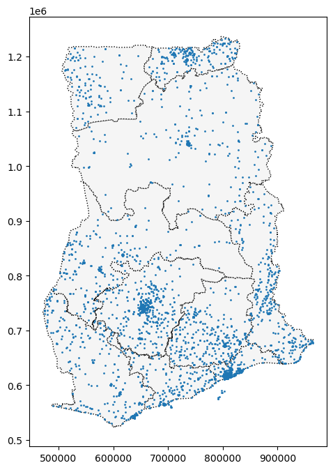

```python
# Create a map
ax = regions.plot(figsize=(8,8), color='whitesmoke', linestyle=':', edgecolor='black')
facilities.to_crs(epsg=32630).plot(markersize=1, ax=ax)
```

```python
# The "Latitude" and "Longitude" columns are unchanged
facilities.to_crs(epsg=32630).head()
```

|  | Region | District | FacilityName | Type | Town | Ownership | Latitude | Longitude | geometry |
| --- | --- | --- | --- | --- | --- | --- | --- | --- | --- |
| 0 | Ashanti | Offinso North | A.M.E Zion Clinic | Clinic | Afrancho | CHAG | 7.40801 | -1.96317 | POINT (614422.662 818986.851) |
| 1 | Ashanti | Bekwai Municipal | Abenkyiman Clinic | Clinic | Anwiankwanta | Private | 6.46312 | -1.58592 | POINT (656373.863 714616.547) |
| 2 | Ashanti | Adansi North | Aboabo Health Centre | Health Centre | Aboabo No 2 | Government | 6.22393 | -1.34982 | POINT (682573.395 688243.477) |
| 3 | Ashanti | Afigya-Kwabre | Aboabogya Health Centre | Health Centre | Aboabogya | Government | 6.84177 | -1.61098 | POINT (653484.490 756478.812) |
| 4 | Ashanti | Kwabre | Aboaso Health Centre | Health Centre | Aboaso | Government | 6.84177 | -1.61098 | POINT (653484.490 756478.812) |

In case the EPSG code is not available in GeoPandas, we can change the CRS with what's known as the "proj4 string" of the CRS. For instance, the proj4 string to convert to latitude/longitude coordinates is as follows:

+proj=longlat +ellps=WGS84 +datum=WGS84 +no_defs

```python
# Change the CRS to EPSG 4326
regions.to_crs("+proj=longlat +ellps=WGS84 +datum=WGS84 +no_defs").head()
```

|  | Region | geometry |
| --- | --- | --- |
| 0 | Ashanti | POLYGON ((-1.30985 7.62302, -1.30786 7.62198, ... |
| 1 | Brong Ahafo | POLYGON ((-2.54567 8.76089, -2.54473 8.76071, ... |
| 2 | Central | POLYGON ((-2.06723 6.29473, -2.06658 6.29420, ... |
| 3 | Eastern | POLYGON ((-0.21751 7.21009, -0.21747 7.20993, ... |
| 4 | Greater Accra | POLYGON ((0.23456 6.10986, 0.23484 6.10974, 0.... |

# Attributes of geometric objects

As you learned in the first tutorial, for an arbitrary GeoDataFrame, the type in the "geometry" column depends on what we are trying to show: for instance, we might use:

- a Point for the epicenter of an earthquake,
- a LineString for a street, or
- a Polygon to show country boundaries. All three types of geometric objects have built-in attributes that you can use to quickly analyze the dataset. For instance, you can get the x- and y-coordinates of a Point from the x and y attributes, respectively.

```python
# Get the x-coordinate of each point
facilities.geometry.head().x
```

```
0   -1.96317
1   -1.58592
2   -1.34982
3   -1.61098
4   -1.61098
dtype: float64
```

```python
# Calculate the area (in square meters) of each polygon in the GeoDataFrame
regions.loc[:, "AREA"] = regions.geometry.area / 10**6

print("Area of Ghana: {} square kilometers".format(regions.AREA.sum()))
print("CRS:", regions.crs)
regions.head()
```

```
Area of Ghana: 239584.5760055668 square kilometers
CRS: epsg:32630
```

|  | Region | geometry | AREA |
| --- | --- | --- | --- |
| 0 | Ashanti | POLYGON ((686446.075 842986.894, 686666.193 84... | 24379.017777 |
| 1 | Brong Ahafo | POLYGON ((549970.457 968447.094, 550073.003 96... | 40098.168231 |
| 2 | Central | POLYGON ((603176.584 695877.238, 603248.424 69... | 9665.626760 |
| 3 | Eastern | POLYGON ((807307.254 797910.553, 807311.908 79... | 18987.625847 |
| 4 | Greater Accra | POLYGON ((858081.638 676424.913, 858113.115 67... | 3706.511145 |

# Interactive Maps

```python
import folium
from folium import Choropleth, Circle, Marker
from folium.plugins import HeatMap, MarkerCluster
```

```python
# Create a map
m_1 = folium.Map(location=[42.32,-71.0589], tiles='openstreetmap', zoom_start=10)

# Display the map
m_1
```

Make this Notebook Trusted to load map: File -> Trust Notebook

[interactive chart not shown]

```python
# Load the data
crimes = pd.read_csv("D:\Project\Spatial\GeospatialKaggle\Data\crimes-in-boston\crimes-in-boston\crime.csv", encoding='latin-1')

# Drop rows with missing locations
crimes.dropna(subset=['Lat', 'Long', 'DISTRICT'], inplace=True)

# Focus on major crimes in 2018
crimes = crimes[crimes.OFFENSE_CODE_GROUP.isin([
    'Larceny', 'Auto Theft', 'Robbery', 'Larceny From Motor Vehicle', 'Residential Burglary',
    'Simple Assault', 'Harassment', 'Ballistics', 'Aggravated Assault', 'Other Burglary',
    'Arson', 'Commercial Burglary', 'HOME INVASION', 'Homicide', 'Criminal Harassment',
    'Manslaughter'])]
crimes = crimes[crimes.YEAR>=2018]

# Print the first five rows of the table
crimes.head()
```

|  | INCIDENT_NUMBER | OFFENSE_CODE | OFFENSE_CODE_GROUP | OFFENSE_DESCRIPTION | DISTRICT | REPORTING_AREA | SHOOTING | OCCURRED_ON_DATE | YEAR | MONTH | DAY_OF_WEEK | HOUR | UCR_PART | STREET | Lat | Long | Location |
| --- | --- | --- | --- | --- | --- | --- | --- | --- | --- | --- | --- | --- | --- | --- | --- | --- | --- |
| 0 | I182070945 | 619 | Larceny | LARCENY ALL OTHERS | D14 | 808 | NaN | 2018-09-02 13:00:00 | 2018 | 9 | Sunday | 13 | Part One | LINCOLN ST | 42.357791 | -71.139371 | (42.35779134, -71.13937053) |
| 6 | I182070933 | 724 | Auto Theft | AUTO THEFT | B2 | 330 | NaN | 2018-09-03 21:25:00 | 2018 | 9 | Monday | 21 | Part One | NORMANDY ST | 42.306072 | -71.082733 | (42.30607218, -71.08273260) |
| 8 | I182070931 | 301 | Robbery | ROBBERY - STREET | C6 | 177 | NaN | 2018-09-03 20:48:00 | 2018 | 9 | Monday | 20 | Part One | MASSACHUSETTS AVE | 42.331521 | -71.070853 | (42.33152148, -71.07085307) |
| 19 | I182070915 | 614 | Larceny From Motor Vehicle | LARCENY THEFT FROM MV - NON-ACCESSORY | B2 | 181 | NaN | 2018-09-02 18:00:00 | 2018 | 9 | Sunday | 18 | Part One | SHIRLEY ST | 42.325695 | -71.068168 | (42.32569490, -71.06816778) |
| 24 | I182070908 | 522 | Residential Burglary | BURGLARY - RESIDENTIAL - NO FORCE | B2 | 911 | NaN | 2018-09-03 18:38:00 | 2018 | 9 | Monday | 18 | Part One | ANNUNCIATION RD | 42.335062 | -71.093168 | (42.33506218, -71.09316781) |

```python
daytime_robberies = crimes[((crimes.OFFENSE_CODE_GROUP == 'Robbery') & \
                            (crimes.HOUR.isin(range(9,18))))]
```

## Plotting points

### folium.Marker

We add markers to the map with folium.Marker(). Each marker below corresponds to a different robbery.

```python
# Create a map
m_2 = folium.Map(location=[42.32,-71.0589], tiles='cartodbpositron', zoom_start=13)

# Add points to the map
for idx, row in daytime_robberies.iterrows():
    Marker([row['Lat'], row['Long']]).add_to(m_2)

# Display the map
m_2
```

Make this Notebook Trusted to load map: File -> Trust Notebook

[interactive chart not shown]

### folium.plugins.MarkerCluster

If we have a lot of markers to add, folium.plugins.MarkerCluster() can help to declutter the map. Each marker is added to a MarkerCluster object.

```python
# Create the map
import math
m_3 = folium.Map(location=[42.32,-71.0589], tiles='cartodbpositron', zoom_start=13)

# Add points to the map
mc = MarkerCluster()
for idx, row in daytime_robberies.iterrows():
    if not math.isnan(row['Long']) and not math.isnan(row['Lat']):
        mc.add_child(Marker([row['Lat'], row['Long']]))
m_3.add_child(mc)

# Display the map
m_3
```

Make this Notebook Trusted to load map: File -> Trust Notebook

[interactive chart not shown]

## Bubble maps

A bubble map uses circles instead of markers. By varying the size and color of each circle, we can also show the relationship between location and two other variables.

We create a bubble map by using folium.Circle() to iteratively add circles. In the code cell below, robberies that occurred in hours 9-12 are plotted in green, whereas robberies from hours 13-17 are plotted in red.

```python
# Create a base map
m_4 = folium.Map(location=[42.32,-71.0589], tiles='cartodbpositron', zoom_start=13)

def color_producer(val):
    if val <= 12:
        return 'forestgreen'
    else:
        return 'darkred'

# Add a bubble map to the base map
for i in range(0,len(daytime_robberies)):
    Circle(
        location=[daytime_robberies.iloc[i]['Lat'], daytime_robberies.iloc[i]['Long']],
        radius=20,
        color=color_producer(daytime_robberies.iloc[i]['HOUR'])).add_to(m_4)

# Display the map
m_4
```

Make this Notebook Trusted to load map: File -> Trust Notebook

[interactive chart not shown]

Note that folium.Circle() takes several arguments:

- location is a list containing the center of the circle, in latitude and longitude.
- radius sets the radius of the circle.
  - Note that in a traditional bubble map, the radius of each circle is allowed to vary. We can implement this by defining a function similar to the color_producer() function that is used to vary the color of each circle.
- color sets the color of each circle.
  - The color_producer() function is used to visualize the effect of the hour on robbery location.

## Heatmaps

To create a heatmap, we use folium.plugins.HeatMap(). This shows the density of crime in different areas of the city, where red areas have relatively more criminal incidents.

As we'd expect for a big city, most of the crime happens near the center.

```python
# Create a base map
m_5 = folium.Map(location=[42.32,-71.0589], tiles='cartodbpositron', zoom_start=12)

# Add a heatmap to the base map
HeatMap(data=crimes[['Lat', 'Long']], radius=10).add_to(m_5)

# Display the map
m_5
```

Make this Notebook Trusted to load map: File -> Trust Notebook

[interactive chart not shown]

As you can see in the code cell above, folium.plugins.HeatMap() takes a couple of arguments:

- data is a DataFrame containing the locations that we'd like to plot.
- radius controls the smoothness of the heatmap. Higher values make the heatmap look smoother (i.e., with fewer gaps).

## Choropleth maps

To understand how crime varies by police district, we'll create a choropleth map.

As a first step, we create a GeoDataFrame where each district is assigned a different row, and the "geometry" column contains the geographical boundaries.

```python
# GeoDataFrame with geographical boundaries of Boston police districts
districts_full = gpd.read_file("D:\Project\Spatial\GeospatialKaggle\Data\Police_Districts\Police_Districts\Police_Districts.shp")
districts = districts_full[["DISTRICT", "geometry"]].set_index("DISTRICT")
districts.head()
```

| DISTRICT | geometry |
| --- | --- |
| A15 | MULTIPOLYGON (((-71.07416 42.39051, -71.07415 ... |
| A7 | MULTIPOLYGON (((-70.99644 42.39557, -70.99644 ... |
| A1 | POLYGON ((-71.05200 42.36884, -71.05169 42.368... |
| C6 | POLYGON ((-71.04406 42.35403, -71.04412 42.353... |
| D4 | POLYGON ((-71.07416 42.35724, -71.07359 42.357... |

We also create a Pandas Series called plot_dict that shows the number of crimes in each district.

```python
# Number of crimes in each police district
plot_dict = crimes.DISTRICT.value_counts()
plot_dict.head()
```

```
D4     2885
B2     2231
A1     2130
C11    1899
B3     1421
Name: DISTRICT, dtype: int64
```

```python
# Create a base map
m_6 = folium.Map(location=[42.32,-71.0589], tiles='cartodbpositron', zoom_start=12)

# Add a choropleth map to the base map
Choropleth(geo_data=districts.__geo_interface__,
           data=plot_dict,
           key_on="feature.id",
           fill_color='YlGnBu',
           legend_name='Major criminal incidents (Jan-Aug 2018)'
          ).add_to(m_6)

# Display the map
m_6
```

Make this Notebook Trusted to load map: File -> Trust Notebook

[interactive chart not shown]

Note that folium.Choropleth() takes several arguments:

- geo_data is a GeoJSON FeatureCollection containing the boundaries of each geographical area.
  - In the code above, we convert the districts GeoDataFrame to a GeoJSON FeatureCollection with the **geo_interface** attribute.
- data is a Pandas Series containing the values that will be used to color-code each geographical area.
- key_on will always be set to feature.id
  - This refers to the fact that the GeoDataFrame used for geo_data and the Pandas Series provided in data have the same index. To understand the details, we'd have to look more closely at the structure of a GeoJSON Feature Collection (where the value corresponding to the "features" key is a list, wherein each entry is a dictionary containing an "id" key).
- fill_color sets the color scale.
- legend_name labels the legend in the top right corner of the map.

# Manipulating Geospatial Data

Find locations with just the name of a place. And, learn how to join data based on spatial relationships.

```python
import pandas as pd
import geopandas as gpd
import numpy as np
import folium
from folium import Marker
import warnings
warnings.filterwarnings('ignore')
```

## Geocoding

```python
from geopy.geocoders import Nominatim
```

```python
geolocator = Nominatim(user_agent="kaggle_learn")
location = geolocator.geocode("Pyramid of Khufu")

print(location.point)
print(location.address)
```

```
29 58m 44.976s N, 31 8m 3.17625s E
هرم خوفو, شارع ابو الهول السياحي, نزلة البطران, الجيزة, 12556, مصر
```

If the geocoding is successful, it returns a geopy.location.Location object with two important attributes:

- the "point" attribute contains the (latitude, longitude) location, and
- the "address" attribute contains the full address.

```python
point = location.point
print("Latitude:", point.latitude)
print("Longitude:", point.longitude)
```

```
Latitude: 29.97916
Longitude: 31.134215625236113
```

```python
universities = pd.read_csv(r"D:\Project\Spatial\GeospatialKaggle\Data\top_universities.csv")
universities.head()
```

|  | Name |
| --- | --- |
| 0 | University of Oxford |
| 1 | University of Cambridge |
| 2 | Imperial College London |
| 3 | ETH Zurich |
| 4 | UCL |

```python
def my_geocoder(row):
    try:
        point = geolocator.geocode(row).point
        return pd.Series({'Latitude': point.latitude, 'Longitude': point.longitude})
    except:
        return None

universities[['Latitude', 'Longitude']] = universities.apply(lambda x: my_geocoder(x['Name']), axis=1)

print("{}% of addresses were geocoded!".format(
    (1 - sum(np.isnan(universities["Latitude"])) / len(universities)) * 100))

# Drop universities that were not successfully geocoded
universities = universities.loc[~np.isnan(universities["Latitude"])]
universities = gpd.GeoDataFrame(
    universities, geometry=gpd.points_from_xy(universities.Longitude, universities.Latitude))
universities.crs = {'init': 'epsg:4326'}
universities.head()
```

```
91.0% of addresses were geocoded!
```

|  | Name | Latitude | Longitude | geometry |
| --- | --- | --- | --- | --- |
| 0 | University of Oxford | 51.752546 | -1.214330 | POINT (-1.21433 51.75255) |
| 1 | University of Cambridge | 52.200623 | 0.110474 | POINT (0.11047 52.20062) |
| 2 | Imperial College London | 51.498959 | -0.175641 | POINT (-0.17564 51.49896) |
| 3 | ETH Zurich | 47.413218 | 8.537491 | POINT (8.53749 47.41322) |
| 4 | UCL | 51.521785 | -0.135151 | POINT (-0.13515 51.52179) |

```python
# Create a map
m = folium.Map(location=[54, 15], tiles='openstreetmap', zoom_start=2)

# Add points to the map
for idx, row in universities.iterrows():
    Marker([row['Latitude'], row['Longitude']], popup=row['Name']).add_to(m)

# Display the map
m
```

Make this Notebook Trusted to load map: File -> Trust Notebook

[interactive chart not shown]

## Table joins

```python
world = gpd.read_file(gpd.datasets.get_path('naturalearth_lowres'))
europe = world.loc[world.continent == 'Europe'].reset_index(drop=True)

europe_stats = europe[["name", "pop_est", "gdp_md_est"]]
europe_boundaries = europe[["name", "geometry"]]

europe_boundaries.head()
```

|  | name | geometry |
| --- | --- | --- |
| 0 | Russia | MULTIPOLYGON (((180.00000 71.51571, 180.00000 ... |
| 1 | Norway | MULTIPOLYGON (((15.14282 79.67431, 15.52255 80... |
| 2 | France | MULTIPOLYGON (((-51.65780 4.15623, -52.24934 3... |
| 3 | Sweden | POLYGON ((11.02737 58.85615, 11.46827 59.43239... |
| 4 | Belarus | POLYGON ((28.17671 56.16913, 29.22951 55.91834... |

```python
europe_stats.head()
```

|  | name | pop_est | gdp_md_est |
| --- | --- | --- | --- |
| 0 | Russia | 144373535.0 | 1699876 |
| 1 | Norway | 5347896.0 | 403336 |
| 2 | France | 67059887.0 | 2715518 |
| 3 | Sweden | 10285453.0 | 530883 |
| 4 | Belarus | 9466856.0 | 63080 |

```python
# Use an attribute join to merge data about countries in Europe
europe = europe_boundaries.merge(europe_stats, on="name")
europe.head()
```

|  | name | geometry | pop_est | gdp_md_est |
| --- | --- | --- | --- | --- |
| 0 | Russia | MULTIPOLYGON (((180.00000 71.51571, 180.00000 ... | 144373535.0 | 1699876 |
| 1 | Norway | MULTIPOLYGON (((15.14282 79.67431, 15.52255 80... | 5347896.0 | 403336 |
| 2 | France | MULTIPOLYGON (((-51.65780 4.15623, -52.24934 3... | 67059887.0 | 2715518 |
| 3 | Sweden | POLYGON ((11.02737 58.85615, 11.46827 59.43239... | 10285453.0 | 530883 |
| 4 | Belarus | POLYGON ((28.17671 56.16913, 29.22951 55.91834... | 9466856.0 | 63080 |

### Spatial join

```python
# Use spatial join to match universities to countries in Europe
european_universities = gpd.sjoin(universities, europe)

# Investigate the result
print("We located {} universities.".format(len(universities)))
print("Only {} of the universities were located in Europe (in {} different countries).".format(
    len(european_universities), len(european_universities.name.unique())))

european_universities.head()
```

```
We located 91 universities.
Only 86 of the universities were located in Europe (in 14 different countries).
```

|  | Name | Latitude | Longitude | geometry | index_right | name | pop_est | gdp_md_est |
| --- | --- | --- | --- | --- | --- | --- | --- | --- |
| 0 | University of Oxford | 51.752546 | -1.214330 | POINT (-1.21433 51.75255) | 28 | United Kingdom | 66834405.0 | 2829108 |
| 1 | University of Cambridge | 52.200623 | 0.110474 | POINT (0.11047 52.20062) | 28 | United Kingdom | 66834405.0 | 2829108 |
| 2 | Imperial College London | 51.498959 | -0.175641 | POINT (-0.17564 51.49896) | 28 | United Kingdom | 66834405.0 | 2829108 |
| 4 | UCL | 51.521785 | -0.135151 | POINT (-0.13515 51.52179) | 28 | United Kingdom | 66834405.0 | 2829108 |
| 5 | London School of Economics and Political Science | 51.514311 | -0.116781 | POINT (-0.11678 51.51431) | 28 | United Kingdom | 66834405.0 | 2829108 |

# Proximity Analysis

Measure distance, and explore neighboring points on a map.

```python
import folium
from folium import Marker, GeoJson
from folium.plugins import HeatMap

import pandas as pd
import geopandas as gpd
```

```python
releases = gpd.read_file(r"D:\Project\Spatial\GeospatialKaggle\Data\toxic_release_pennsylvania\toxic_release_pennsylvania\toxic_release_pennsylvania.shp")
releases.head()
```

|  | YEAR | CITY | COUNTY | ST | LATITUDE | LONGITUDE | CHEMICAL | UNIT_OF_ME | TOTAL_RELE | geometry |
| --- | --- | --- | --- | --- | --- | --- | --- | --- | --- | --- |
| 0 | 2016 | PHILADELPHIA | PHILADELPHIA | PA | 40.005901 | -75.072103 | FORMIC ACID | Pounds | 0.160 | POINT (2718560.227 256380.179) |
| 1 | 2016 | PHILADELPHIA | PHILADELPHIA | PA | 39.920120 | -75.146410 | ETHYLENE GLYCOL | Pounds | 13353.480 | POINT (2698674.606 224522.905) |
| 2 | 2016 | PHILADELPHIA | PHILADELPHIA | PA | 40.023880 | -75.220450 | CERTAIN GLYCOL ETHERS | Pounds | 104.135 | POINT (2676833.394 261701.856) |
| 3 | 2016 | PHILADELPHIA | PHILADELPHIA | PA | 39.913540 | -75.198890 | LEAD COMPOUNDS | Pounds | 1730.280 | POINT (2684030.004 221697.388) |
| 4 | 2016 | PHILADELPHIA | PHILADELPHIA | PA | 39.913540 | -75.198890 | BENZENE | Pounds | 39863.290 | POINT (2684030.004 221697.388) |

```python
stations = gpd.read_file("D:\Project\Spatial\GeospatialKaggle\Data\PhillyHealth_Air_Monitoring_Stations\PhillyHealth_Air_Monitoring_Stations\PhillyHealth_Air_Monitoring_Stations.shp")
stations.head()
```

|  | SITE_NAME | ADDRESS | BLACK_CARB | ULTRAFINE_ | CO | SO2 | OZONE | NO2 | NOY_NO | PM10 | ... | PAMS_VOC | TSP_11101 | TSP_METALS | TSP_LEAD | TOXICS_TO1 | MET | COMMUNITY_ | LATITUDE | LONGITUDE | geometry |
| --- | --- | --- | --- | --- | --- | --- | --- | --- | --- | --- | --- | --- | --- | --- | --- | --- | --- | --- | --- | --- | --- |
| 0 | LAB | 1501 East Lycoming Avenue | N | N | Y | N | Y | Y | Y | N | ... | Y | N | Y | N | y | N | N | 40.008606 | -75.097624 | POINT (2711384.641 257149.310) |
| 1 | ROX | Eva and Dearnley Streets | N | N | N | N | N | N | N | N | ... | N | N | Y | N | Y | N | N | 40.050461 | -75.236966 | POINT (2671934.290 271248.900) |
| 2 | NEA | Grant Avenue and Ashton Street | N | N | N | N | Y | N | N | N | ... | N | N | N | N | N | Y | N | 40.072073 | -75.013128 | POINT (2734326.638 280980.247) |
| 3 | CHS | 500 South Broad Street | N | N | N | N | N | N | N | N | ... | N | N | Y | N | Y | N | N | 39.944510 | -75.165442 | POINT (2693078.580 233247.101) |
| 4 | NEW | 2861 Lewis Street | N | N | Y | Y | Y | N | Y | Y | ... | N | Y | N | Y | N | Y | N | 39.991688 | -75.080378 | POINT (2716399.773 251134.976) |

5 rows × 24 columns

## Measuring distance

```python
print(stations.crs)
print(releases.crs)
```

```
epsg:2272
epsg:2272
```

To measure distances between points from two different GeoDataFrames, we first have to make sure that they use the same coordinate reference system (CRS). Thankfully, this is the case here, where both use EPSG 2272.

```python
# Select one release incident in particular
recent_release = releases.iloc[360]

# Measure distance from release to each station
distances = stations.geometry.distance(recent_release.geometry)
distances
```

```
0     44778.509761
1     51006.456589
2     77744.509207
3     14672.170878
4     43753.554393
5      4711.658655
6     23197.430858
7     12072.823097
8     79081.825506
9      3780.623591
10    27577.474903
11    19818.381002
dtype: float64
```

```python
print('Mean distance to monitoring stations: {} feet'.format(distances.mean()))
```

```
Mean distance to monitoring stations: 33516.28487007786 feet
```

```python
print('Closest monitoring station ({} feet):'.format(distances.min()))
print(stations.iloc[distances.idxmin()][["ADDRESS", "LATITUDE", "LONGITUDE"]])
```

```
Closest monitoring station (3780.623590556444 feet):
ADDRESS      3100 Penrose Ferry Road
LATITUDE                    39.91279
LONGITUDE                 -75.185448
Name: 9, dtype: object
```

## Creating a buffer

If we want to understand all points on a map that are some radius away from a point, the simplest way is to create a buffer.

The code cell below creates a GeoSeries two_mile_buffer containing 12 different Polygon objects. Each polygon is a buffer of 2 miles (or, 2*5280 feet) around a different air monitoring station.

```python
two_mile_buffer = stations.geometry.buffer(2*5280)
two_mile_buffer.head()
```

```
0    POLYGON ((2721944.641 257149.310, 2721893.792 ...
1    POLYGON ((2682494.290 271248.900, 2682443.441 ...
2    POLYGON ((2744886.638 280980.247, 2744835.789 ...
3    POLYGON ((2703638.580 233247.101, 2703587.731 ...
4    POLYGON ((2726959.773 251134.976, 2726908.924 ...
dtype: geometry
```

We use folium.GeoJson() to plot each polygon on a map. Note that since folium requires coordinates in latitude and longitude, we have to convert the CRS to EPSG 4326 before plotting.

```python
# Create map with release incidents and monitoring stations
m = folium.Map(location=[39.9526,-75.1652], zoom_start=11)
HeatMap(data=releases[['LATITUDE', 'LONGITUDE']], radius=15).add_to(m)
for idx, row in stations.iterrows():
    Marker([row['LATITUDE'], row['LONGITUDE']]).add_to(m)

# Plot each polygon on the map
GeoJson(two_mile_buffer.to_crs(epsg=4326)).add_to(m)

# Show the map
m
```

Make this Notebook Trusted to load map: File -> Trust Notebook

[interactive chart not shown]

Now, to test if a toxic release occurred within 2 miles of any monitoring station, we could run 12 different tests for each polygon (to check individually if it contains the point).

But a more efficient way is to first collapse all of the polygons into a MultiPolygon object. We do this with the unary_union attribute.

```python
# Turn group of polygons into single multipolygon
my_union = two_mile_buffer.geometry.unary_union
print('Type:', type(my_union))

# Show the MultiPolygon object
my_union
```

```
Type: <class 'shapely.geometry.multipolygon.MultiPolygon'>
```

We use the contains() method to check if the multipolygon contains a point. We'll use the release incident from earlier in the tutorial, which we know is roughly 3781 feet to the closest monitoring station.

```python
# The closest station is less than two miles away
my_union.contains(releases.iloc[360].geometry)
```

```
True
```

```python
# The closest station is more than two miles away
my_union.contains(releases.iloc[358].geometry)
```

```
False
```